# MetAlyzer User Guide

Nils Mechtel, Carolin Andresen & Luis Herfurth

2024-03-10

The package provides methods to read output files from the MetIDQ™ software into R. Metabolomics data is read and reformatted into an S4 object for convenient data handling, statistics and downstream analysis.

## Install

There is a version available on CRAN.

```r
install.packages("MetAlyzer")
```

The latest version can directly be installed from the github.

```r
library(devtools)
install_github("nilsmechtel/MetAlyzer")
```

## Overview

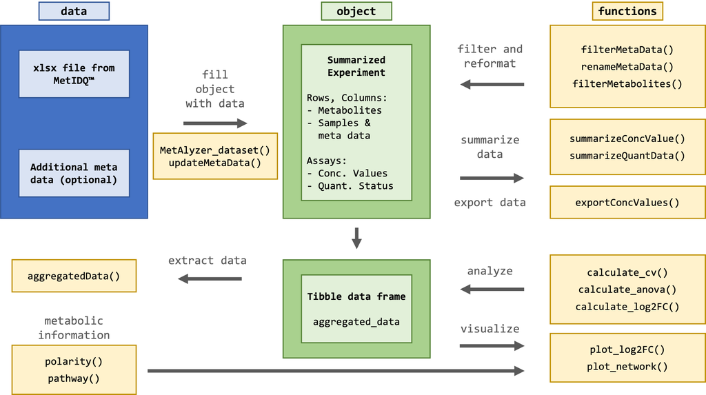

The package takes metabolomic measurements as “.xlsx” files generated from the MetIDQ™ software. Additionally, meta data for each sample can be provided for further analysis.

Effective quantification of metabolites requires a reliable signal. The limit of detection (LOD) is defined as 3 times signal-to-noise of the baseline, calculated by the software MetIDQ™ for each metabolite. Values are classified as “Valid”, “LOQ” (below limit of quantification) or “LOD” (below limit of detection). This information is encoded in the color in the “.xlsx” table. Further color codes can include “ISTD Out of Range”, “Invalid” and “Incomplete”. The MetAlyzer packages allow to read both information, the value and the quantification status, gives statistics about the quantification efficacy and allows filtering based on the LOD.

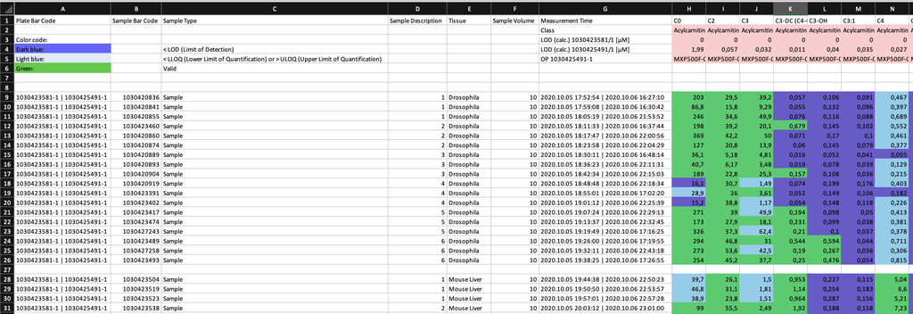

Example of excel sheet.

## Get started

To present the base functionalities of MetAlyzer, we use a data set published by [Gegner *et al*. 2022](https://www.frontiersin.org/articles/10.3389/fchem.2022.869732/full). This data set was analyzed using the MxP®Quant 500 kit and inlcudes 6 different extraction methods (1 to 6) to quantify 630 metabolites in triplicates for 4 tissue types (Drosophila, Mouse Liver, Mouse Kidney, Zebrafish Liver). It is included in the MetAlyzer package and can be accessed via `example_extraction_data()`. `MetAlyzer_dataset` reads the data from Excel into R and stores it as a SummarizedExperiment (SE).

```r
fpath <- example_extraction_data()
metalyzer_se <- MetAlyzer_dataset(file_path = fpath)
```

```
#>
#>
#>  _____ ______   _______  _________  ________  ___           ___    ___ ________  _______   ________
#> |\   _ \  _   \|\  ___ \|\___   ___\\   __  \|\  \         |\  \  /  /|\_____  \|\  ___ \ |\   __  \
#> \ \  \\\__\ \  \ \   __/\|___ \  \_\ \  \|\  \ \  \        \ \  \/  / /\|___/  /\ \   __/|\ \  \|\  \
#>  \ \  \\|__| \  \ \  \_|/__  \ \  \ \ \   __  \ \  \        \ \    / /     /  / /\ \  \_|/_\ \   _  _\
#>   \ \  \    \ \  \ \  \_|\ \  \ \  \ \ \  \ \  \ \  \____    \/   / /     /  /_/__\ \  \_|\ \ \  \\  \|
#>    \ \__\    \ \__\ \_______\  \ \__\ \ \__\ \__\ \_______\__/   / /     |\________\ \_______\ \__\\ _\
#>     \|__|     \|__|\|_______|   \|__|  \|__|\|__|\|_______|\____/ /       \|_______|\|_______|\|__|\|__|
#>                                                           \|____|/
#>
#>
#> Info: Reading color code "FFFFCCCC" as "#FFCCCC"
#> Info: Reading color code "FF00CD66" as "#00CD66"
#> Info: Reading color code "FF6A5ACD" as "#6A5ACD"
#> Info: Reading color code "FF87CEEB" as "#87CEEB"
#> Info: Reading color code "FFFFFFCC" as "#FFFFCC"
#>
#> Measured concentration values:
#> ------------------------------
#>         0%        25%        50%        75%       100%
#>      0.000      0.017      1.760     21.200 288149.000
#>
#> NAs: 5348 (8.38%)
#> Note: 'Metabolism Indicators' are frequently NA!
#>
#> Measured quantification status:
#> -------------------------------
#> Valid: 24095 (37.77%)
#> LOQ: 5799 (9.09%)
#> LOD: 21789 (34.16%)
#> Invalid: 12105 (18.98%)
#> NAs: 0 (0%)
```

```r
metalyzer_se
```

```
#> class: SummarizedExperiment
#> dim: 862 74
#> metadata(4): file_path sheet_index status_list aggregated_data
#> assays(2): conc_values quant_status
#> rownames(862): C0 C2 ... Sum of TGs Sum of Unsaturated TGs
#> rowData names(1): metabolic_classes
#> colnames(74): 9 10 ... 89 90
#> colData names(7): Plate Bar Code Sample Bar Code ... Sample Volume Measurement Time
```

The SE includes assay information with concentration values and quantification status, while storing metabolites and their respective classes in the row data. It is important to note that there are 630 metabolites, and 232 metabolite indicators calculated using the MetIDQ™ software. Sample-wise metadata is stored in the column data. Additional data such as the file path (*‘file_path’*), the Excel sheet number (*‘sheet_index’*), a list of colors for each quantification status (*status_list*), as well as a tibble of aggregated concentration data and quantification status for downstream analysis and visualizations (*‘aggregated_data’*) are stored in the SE’s metadata.

Summaries of concentration values and quantification status are automatically called during data loading, but can also manually be called using `summarizeConcValues(metalyzer_se)` and `summarizeQuantData(metalyzer_se)`. The function `summarizeConcValues` prints the quantiles and the amount / percentage of NAs in the concentration data. The function `summarizeQuantData` gives an overview of the quantification status of the metabolites. E.g 34.16% of metabolites where below the Limit of Detection.

The various elements within the SummarizedExperiment (SE) can be accessed in a manner consistent with a typical SE.

```r
meta_data <- colData(metalyzer_se)
head(meta_data)
```

```
#> DataFrame with 6 rows and 7 columns
#>            Plate Bar Code Sample Bar Code Sample Type Sample Description      Tissue Sample Volume       Measurement Time
#>               <character>     <character> <character>        <character> <character>   <character>            <character>
#> 9  1030423581-1 | 10304..      1030420836      Sample                  1  Drosophila            10 2020.10.05 17:52:54 ..
#> 10 1030423581-1 | 10304..      1030420841      Sample                  1  Drosophila            10 2020.10.05 17:59:08 ..
#> 11 1030423581-1 | 10304..      1030420855      Sample                  1  Drosophila            10 2020.10.05 18:05:19 ..
#> 12 1030423581-1 | 10304..      1030423460      Sample                  2  Drosophila            10 2020.10.05 18:11:33 ..
#> 13 1030423581-1 | 10304..      1030420860      Sample                  2  Drosophila            10 2020.10.05 18:17:47 ..
#> 14 1030423581-1 | 10304..      1030420874      Sample                  2  Drosophila            10 2020.10.05 18:23:58 ..
```

```r
metabolites <- rowData(metalyzer_se)
head(metabolites)
```

```
#> DataFrame with 6 rows and 1 column
#>               metabolic_classes
#>                     <character>
#> C0               Acylcarnitines
#> C2               Acylcarnitines
#> C3               Acylcarnitines
#> C3-DC (C4-OH)    Acylcarnitines
#> C3-OH            Acylcarnitines
#> C3:1             Acylcarnitines
```

```r
concentration_values <- assays(metalyzer_se)$conc_values
head(concentration_values, c(5, 5))
```

```
#>                     9     10      11      12      13
#> C0            203.000 86.800 246.000 198.000 369.000
#> C2             29.500 15.800  34.600  39.200  42.200
#> C3             39.200  9.290  49.900  20.100  50.000
#> C3-DC (C4-OH)   0.057  0.055   0.076   0.679   0.071
#> C3-OH           0.106  0.132   0.116   0.145   0.170
```

```r
quantification_status <- assays(metalyzer_se)$quant_status
head(quantification_status, c(5, 5))
```

```
#>               9       10      11      12      13
#> C0            "Valid" "Valid" "Valid" "Valid" "Valid"
#> C2            "Valid" "Valid" "Valid" "Valid" "Valid"
#> C3            "Valid" "Valid" "Valid" "Valid" "Valid"
#> C3-DC (C4-OH) "LOD"   "LOD"   "LOD"   "Valid" "LOD"
#> C3-OH         "LOD"   "LOD"   "LOD"   "LOD"   "LOD"
```

In addition to accessing the aggregated data through `metadata(metalyzer_se)$aggregated_data`, it can be directly accessed using *aggregatedData*.

```r
aggregated_data <- aggregatedData(metalyzer_se)
head(aggregated_data)
```

```
#> # A tibble: 6 × 5
#> # Groups:   Metabolite [1]
#>   ID    Metabolite Class          Concentration Status
#>   <fct> <fct>      <fct>                  <dbl> <fct>
#> 1 9     C0         Acylcarnitines         203   Valid
#> 2 10    C0         Acylcarnitines          86.8 Valid
#> 3 11    C0         Acylcarnitines         246   Valid
#> 4 12    C0         Acylcarnitines         198   Valid
#> 5 13    C0         Acylcarnitines         369   Valid
#> 6 14    C0         Acylcarnitines         127   Valid
```

### Manage metabolites and sample-wise meta data

The functions `filterMetabolites` and `filterMetaData` can be used to subset the data set based on certain metabolites or meta variables. Both functions subset *conc_values*, *quant_status* and *aggregated_data*.

Individual metabolites as well as metabolic classes can be passed to `filterMetabolites`. Here, we want to exclude the metabolism indicators.

```r
metalyzer_se <- filterMetabolites(metalyzer_se, drop_metabolites = "Metabolism Indicators")
```

```
#> Info: 232 metabolites were removed!
```

```r
metalyzer_se
```

```
#> class: SummarizedExperiment
#> dim: 630 74
#> metadata(4): file_path sheet_index status_list aggregated_data
#> assays(2): conc_values quant_status
#> rownames(630): C0 C2 ... TG(22:6_34:3) Choline
#> rowData names(1): metabolic_classes
#> colnames(74): 9 10 ... 89 90
#> colData names(7): Plate Bar Code Sample Bar Code ... Sample Volume Measurement Time
```

The extraction methods are encoded in the column “Sample Description” of the meta data. There are 2 blank samples in the data that we want to remove and only keep extraction method 1 to 6.

```r
metalyzer_se <- filterMetaData(metalyzer_se, `Sample Description` %in% 1:6)
```

```
#> Info: 2 samples were removed!
```

To be more specific and for easier handling, we change the column “Sample Description” of the meta data to “Extraction_Method”.

```r
metalyzer_se <- renameMetaData(metalyzer_se, "Extraction_Method" = "Sample Description")

meta_data <- colData(metalyzer_se)
head(meta_data)
```

```
#> DataFrame with 6 rows and 7 columns
#>            Plate Bar Code Sample Bar Code Sample Type Extraction_Method      Tissue Sample Volume       Measurement Time
#>               <character>     <character> <character>       <character> <character>   <character>            <character>
#> 9  1030423581-1 | 10304..      1030420836      Sample                 1  Drosophila            10 2020.10.05 17:52:54 ..
#> 10 1030423581-1 | 10304..      1030420841      Sample                 1  Drosophila            10 2020.10.05 17:59:08 ..
#> 11 1030423581-1 | 10304..      1030420855      Sample                 1  Drosophila            10 2020.10.05 18:05:19 ..
#> 12 1030423581-1 | 10304..      1030423460      Sample                 2  Drosophila            10 2020.10.05 18:11:33 ..
#> 13 1030423581-1 | 10304..      1030420860      Sample                 2  Drosophila            10 2020.10.05 18:17:47 ..
#> 14 1030423581-1 | 10304..      1030420874      Sample                 2  Drosophila            10 2020.10.05 18:23:58 ..
```

Additional meta data can be easily added to the Summarized Experiment. Here, we want to add the column “Date” with the current date to the meta data as well as the column “Replicate” with extraction method replicates.

```r
replicate_meta_data <- example_meta_data()
head(replicate_meta_data)
```

```
#>   Method Replicate
#> 1      1        R1
#> 2      1        R2
#> 3      1        R3
#> 4      2        R1
#> 5      2        R2
#> 6      2        R3
```

```r
metalyzer_se <- updateMetaData(
  metalyzer_se,
  Date = Sys.Date(),
  Replicate = replicate_meta_data$Replicate
)

meta_data <- colData(metalyzer_se)
head(meta_data)
```

```
#> DataFrame with 6 rows and 9 columns
#>            Plate Bar Code Sample Bar Code Sample Type Extraction_Method      Tissue Sample Volume       Measurement Time
#>               <character>     <character> <character>       <character> <character>   <character>            <character>
#> 9  1030423581-1 | 10304..      1030420836      Sample                 1  Drosophila            10 2020.10.05 17:52:54 ..
#> 10 1030423581-1 | 10304..      1030420841      Sample                 1  Drosophila            10 2020.10.05 17:59:08 ..
#> 11 1030423581-1 | 10304..      1030420855      Sample                 1  Drosophila            10 2020.10.05 18:05:19 ..
#> 12 1030423581-1 | 10304..      1030423460      Sample                 2  Drosophila            10 2020.10.05 18:11:33 ..
#> 13 1030423581-1 | 10304..      1030420860      Sample                 2  Drosophila            10 2020.10.05 18:17:47 ..
#> 14 1030423581-1 | 10304..      1030420874      Sample                 2  Drosophila            10 2020.10.05 18:23:58 ..
#>          Date Replicate
#>      <factor>  <factor>
#> 9  2024-03-10        R1
#> 10 2024-03-10        R2
#> 11 2024-03-10        R3
#> 12 2024-03-10        R1
#> 13 2024-03-10        R2
#> 14 2024-03-10        R3
```

### Analysis of extraction methods

MetAlyzer includes functions to perform data analysis as it was performed for [MetaboExtract](https://www.metaboextract.shiny.dkfz.de/MetaboExtract/) ([Andresen *et al*. 2022](https://www.frontiersin.org/articles/10.3389/fmolb.2022.932261/full)). All analysing functions in MetAlyzer use the aggregated concentration data and quantification status (*‘aggregated_data’*). The `calculate_cv` calculates the mean, standard deviation (SD) and the coefficient of variation (CV) within each group and saves it to *‘aggregated_data’*. Each group is additionally categorized into given thresholds of variation based on the calculated CV.

```r
metalyzer_se <- calculate_cv(
  metalyzer_se,
  groups = c("Tissue", "Extraction_Method", "Metabolite"),
  cv_thresholds = c(0.1, 0.2, 0.3),
  na.rm = TRUE
)
```

```
#> Info: Calculating mean and coefficient of variation (groupwise: Tissue * Extraction_Method * Metabolite)...  finished!
```

```r
aggregated_data <- aggregatedData(metalyzer_se) %>%
  select(c(Extraction_Method, Metabolite, Mean, SD, CV, CV_thresh))
head(aggregated_data)
```

```
#> # A tibble: 6 × 7
#> # Groups:   Tissue, Extraction_Method, Metabolite [2]
#>   Tissue     Extraction_Method Metabolite  Mean    SD    CV CV_thresh
#>   <fct>      <fct>             <fct>      <dbl> <dbl> <dbl> <fct>
#> 1 Drosophila 1                 C0          179.  82.4 0.461 more30
#> 2 Drosophila 1                 C0          179.  82.4 0.461 more30
#> 3 Drosophila 1                 C0          179.  82.4 0.461 more30
#> 4 Drosophila 2                 C0          231. 124.  0.538 more30
#> 5 Drosophila 2                 C0          231. 124.  0.538 more30
#> 6 Drosophila 2                 C0          231. 124.  0.538 more30
```

As described in [Gegner *et al*.](https://www.frontiersin.org/articles/10.3389/fchem.2022.869732/full), an ANOVA is calculated to identify extraction methods with superior and inferior extraction performance. NAs or zero values are first imputed, to avoid NAs during log2 transformation. To impute NAs, the *impute_NA* argument can be set to TRUE. The argument *impute_perc_of_min* specifies the percentage of the minimum concentration value that is used for imputation.

```r
metalyzer_se <- calculate_anova(
  metalyzer_se,
  categorical = "Extraction_Method",
  groups = c("Tissue", "Metabolite"),
  impute_perc_of_min = 0.2,
  impute_NA = TRUE
)
```

```
#> Info: Imputing concentrations (groupwise: Metabolite) with 20% of the minimal positive value...  finished!
#> Info: Calculating ANOVA (groupwise: Tissue * Metabolite)...  finished!
```

```r
aggregated_data <- aggregatedData(metalyzer_se) %>%
  select(c(Extraction_Method, Metabolite, imputed_Conc, log2_Conc, ANOVA_n, ANOVA_Group))
head(aggregated_data)
```

```
#> # A tibble: 6 × 7
#> # Groups:   Tissue, Metabolite, Extraction_Method [2]
#>   Tissue     Extraction_Method Metabolite imputed_Conc log2_Conc ANOVA_n ANOVA_Group
#>   <fct>      <fct>             <fct>             <dbl>     <dbl>   <int> <chr>
#> 1 Drosophila 1                 C0                203        7.67       3 A
#> 2 Drosophila 1                 C0                 86.8      6.44       3 A
#> 3 Drosophila 1                 C0                246        7.94       3 A
#> 4 Drosophila 2                 C0                198        7.63       3 A
#> 5 Drosophila 2                 C0                369        8.53       3 A
#> 6 Drosophila 2                 C0                127        6.99       3 A
```

The result of the imputation is stored in an extra column “imputed_Conc”. In total 12,212 zero values were imputed in this example.

```r
cat("Number of zero values before imputation:",
    sum(aggregatedData(metalyzer_se)$Concentration == 0, na.rm = TRUE), "\n")
```

```
#> Number of zero values before imputation: 12212
```

```r
cat("Number of zero values after imputation:",
    sum(aggregatedData(metalyzer_se)$imputed_Conc == 0, na.rm = TRUE), "\n")
```

```
#> Number of zero values after imputation: 0
```

### Analysis and visualization of treatment data

```r
fpath <- example_mutation_data_xl()
metalyzer_se <- MetAlyzer_dataset(file_path = fpath)
```

```
#>
#>
#>  _____ ______   _______  _________  ________  ___           ___    ___ ________  _______   ________
#> |\   _ \  _   \|\  ___ \|\___   ___\\   __  \|\  \         |\  \  /  /|\_____  \|\  ___ \ |\   __  \
#> \ \  \\\__\ \  \ \   __/\|___ \  \_\ \  \|\  \ \  \        \ \  \/  / /\|___/  /\ \   __/|\ \  \|\  \
#>  \ \  \\|__| \  \ \  \_|/__  \ \  \ \ \   __  \ \  \        \ \    / /     /  / /\ \  \_|/_\ \   _  _\
#>   \ \  \    \ \  \ \  \_|\ \  \ \  \ \ \  \ \  \ \  \____    \/   / /     /  /_/__\ \  \_|\ \ \  \\  \|
#>    \ \__\    \ \__\ \_______\  \ \__\ \ \__\ \__\ \_______\__/   / /     |\________\ \_______\ \__\\ _\
#>     \|__|     \|__|\|_______|   \|__|  \|__|\|__|\|_______|\____/ /       \|_______|\|_______|\|__|\|__|
#>                                                           \|____|/
#>
#>
#> Info: Reading color code "FFCBD2D7" as "#CBD2D7"
#> Info: Reading color code "FF7FB2C5" as "#7FB2C5"
#> Info: Reading color code "FFCBD2D7" as "#CBD2D7"
#> Info: Reading color code "FFB9DE83" as "#B9DE83"
#> Info: Reading color code "FFB9DE83" as "#B9DE83"
#> Info: Reading color code "FFA28BA3" as "#A28BA3"
#> Info: Reading color code "FFA28BA3" as "#A28BA3"
#> Info: Reading color code "FFB2D1DC" as "#B2D1DC"
#> Info: Reading color code "FFB2D1DC" as "#B2D1DC"
#> Info: Reading color code "FF7FB2C5" as "#7FB2C5"
#>
#> Measured concentration values:
#> ------------------------------
#>        0%       25%       50%       75%      100%
#>      0.00      1.63      7.77     43.07 139200.40
#>
#> NAs: 155 (0.85%)
#>
#>
#> Measured quantification status:
#> -------------------------------
#> Valid: 14280 (77.85%)
#> LOQ: 819 (4.47%)
#> LOD: 3243 (17.68%)
#> NAs: 0 (0%)
```

```r
metalyzer_se
```

```
#> class: SummarizedExperiment
#> dim: 1019 18
#> metadata(4): file_path sheet_index status_list aggregated_data
#> assays(2): conc_values quant_status
#> rownames(1019): C0 C2 ... TG 22:6_34:3 Choline
#> rowData names(1): metabolic_classes
#> colnames(18): 32 33 ... 48 49
#> colData names(11): Plate bar code Sample bar code ... Org. info Measurement time
```

Again, we want to remove the metabolism indicators.

```r
metalyzer_se <- filterMetabolites(metalyzer_se, drop_metabolites = "Metabolism Indicators")
```

```
#> Info: No metabolites were removed!
```

```r
metalyzer_se
```

```
#> class: SummarizedExperiment
#> dim: 1019 18
#> metadata(4): file_path sheet_index status_list aggregated_data
#> assays(2): conc_values quant_status
#> rownames(1019): C0 C2 ... TG 22:6_34:3 Choline
#> rowData names(1): metabolic_classes
#> colnames(18): 32 33 ... 48 49
#> colData names(11): Plate bar code Sample bar code ... Org. info Measurement time
```

In this data set, the column “Sample Description” holds information about the wether a sample is a wild type or a mutant.

```r
meta_data <- colData(metalyzer_se)
meta_data$`Sample Description`
```

```
#>  [1] "Mutant"  "Mutant"  "Mutant"  "Mutant"  "Mutant"  "Mutant"  "Mutant"  "Mutant"  "Mutant"  "Control" "Control" "Control"
#> [13] "Control" "Control" "Control" "Control" "Control" "Control"
```

```r
control_mutant <- factor(colData(metalyzer_se)$`Sample Description`, levels = c("Control", "Mutant"))
metalyzer_se <- updateMetaData(metalyzer_se, Control_Mutant = control_mutant)

meta_data <- colData(metalyzer_se)
meta_data$Control_Mutant
```

```
#>  [1] Mutant  Mutant  Mutant  Mutant  Mutant  Mutant  Mutant  Mutant  Mutant  Control Control Control Control Control Control
#> [16] Control Control Control
#> Levels: Control Mutant
```

In order to avoid NAs during log2 transformation the same imputation of NAs or zero values is applied as for `calculate_anova`. To impute NAs, the *impute_NA* argument can be set to TRUE. The argument *impute_perc_of_min* specifies the percentage of the minimum concentration value that is used for imputation.

```r
metalyzer_se <- calculate_log2FC(
  metalyzer_se,
  categorical = "Control_Mutant",
  impute_perc_of_min = 0.2,
  impute_NA = TRUE
)
```

```
#> Info: Imputing concentrations (groupwise: Metabolite) with 20% of the minimal positive value...  finished!
#> Info: Calculating log2 fold change from Mutant to Control (column: Control_Mutant).
#> Info: Calculating log2 fold change groupwise (Metabolite) using a linear model...  finished!
```

In addition to accessing the log2 fold change data through `metadata(metalyzer_se)$log2FC`, it can be directly accessed using `log2FC`.

```r
log2FC(metalyzer_se)
```

```
#> # A tibble: 1,019 × 5
#>    Metabolite    Class           log2FC   pval  qval
#>    <fct>         <fct>            <dbl>  <dbl> <dbl>
#>  1 C0            Acylcarnitines -0.0953 0.694  0.838
#>  2 C2            Acylcarnitines  0.323  0.431  0.643
#>  3 C3            Acylcarnitines -0.351  0.219  0.488
#>  4 C3-DC (C4-OH) Acylcarnitines  0.315  0.420  0.633
#>  5 C3-OH         Acylcarnitines  0.593  0.460  0.667
#>  6 C3:1          Acylcarnitines  0.203  0.781  0.894
#>  7 C4            Acylcarnitines  0.240  0.185  0.462
#>  8 C4:1          Acylcarnitines  1.11   0.365  0.585
#>  9 C5            Acylcarnitines  0.115  0.628  0.791
#> 10 C5-DC (C6-OH) Acylcarnitines  0.342  0.0498 0.272
#> # ℹ 1,009 more rows
```

The log2 fold change between the wild type and the mutant can be visualized with a volcano plot:

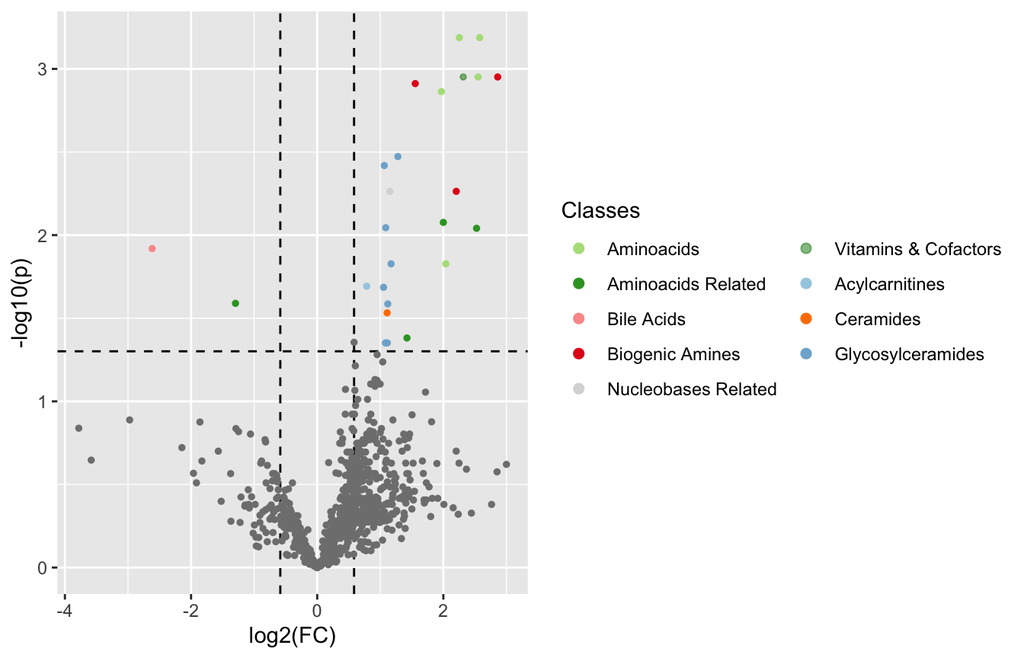

```r
log2fc_vulcano <- plot_log2FC(
  metalyzer_se,
  hide_labels_for = rownames(rowData(metalyzer_se)),
  vulcano=TRUE
)

log2fc_vulcano
```

as well as in a scatter plot categorized by metabolic classes:

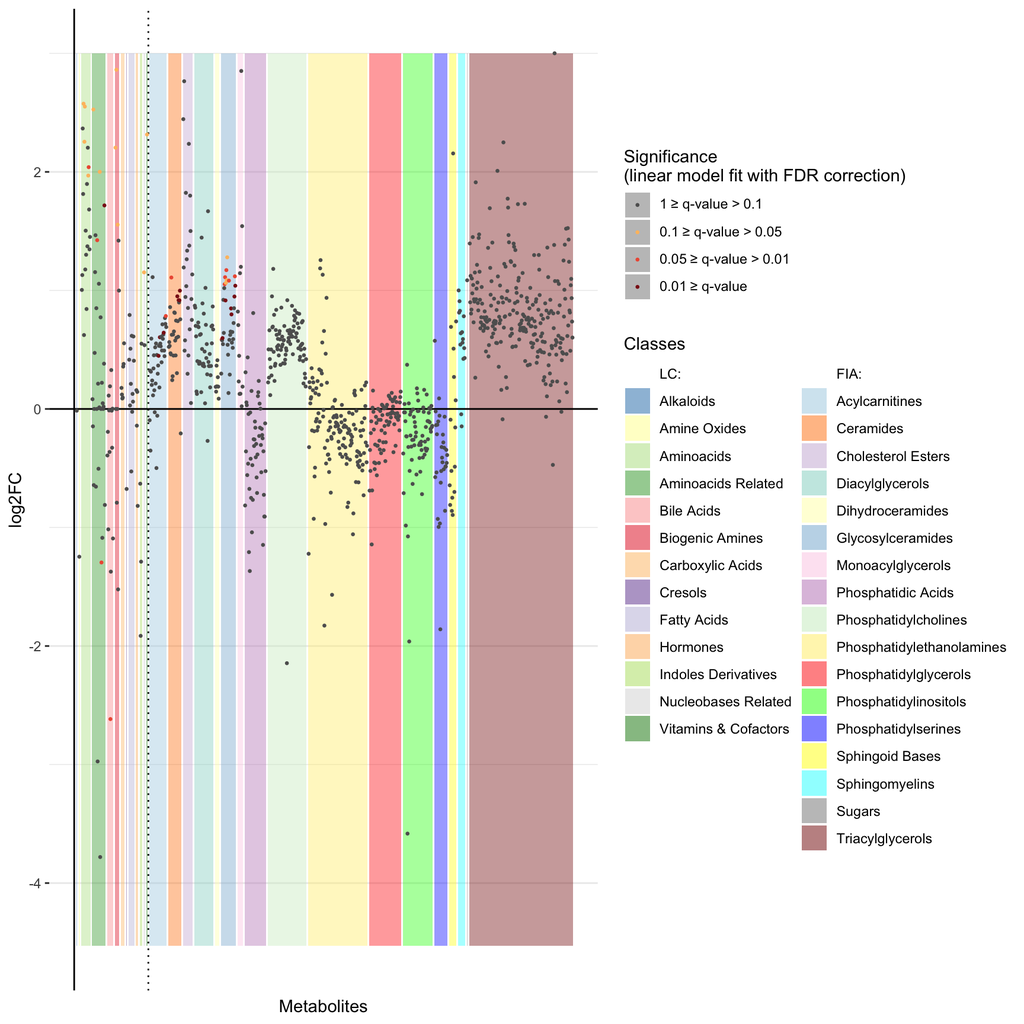

```r
log2fc_by_class <- plot_log2FC(
  metalyzer_se,
  hide_labels_for = rownames(rowData(metalyzer_se)),
  vulcano=FALSE
)

log2fc_by_class
```

MetAlyzer also provides a visualization of the log2 fold change across different pathways, in order to identify groups of metabolites impacted by the effect.

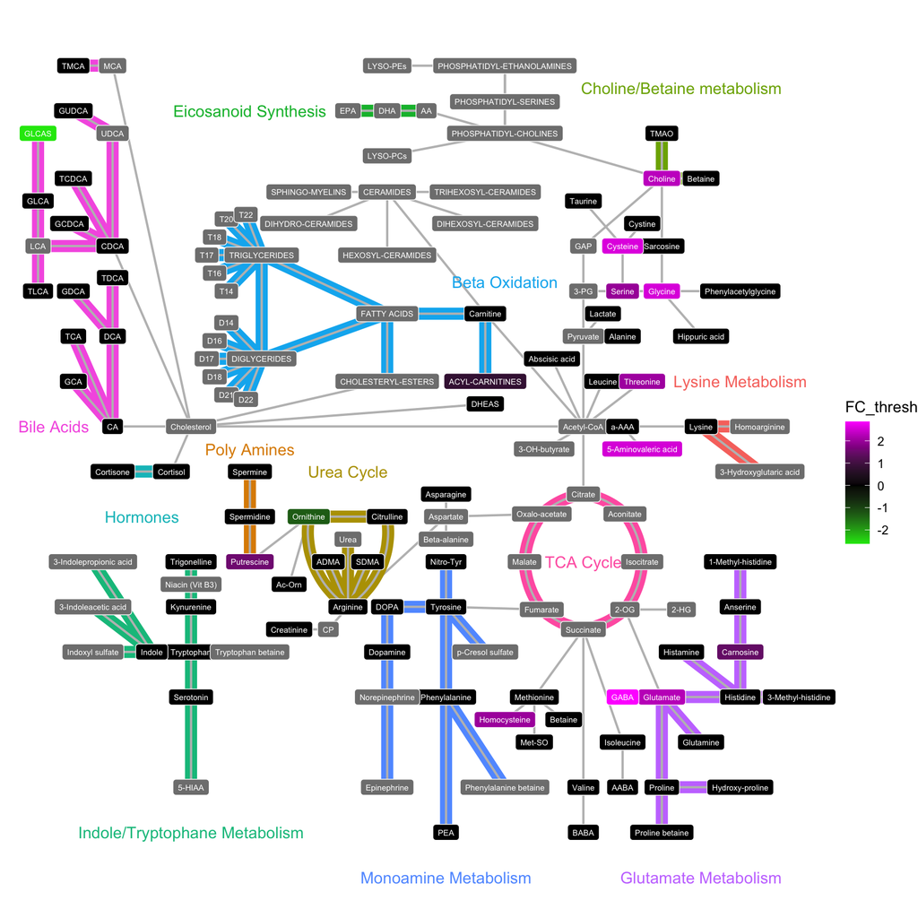

```r
log2fc_network <- plot_network(
  metalyzer_se,
  q_value=0.05,
  metabolite_text_size=2,
  connection_width=0.75,
  pathway_text_size=4,
  pathway_width=4,
  scale_colors = c("green", "black", "magenta")
)
log2fc_network
```